# Компьютерная работа №1 Многомерные статистические методы 2020-21 гг. — 2 курс

## **1. Постановка задачи**

На первом этапе необходимо импортировать все необходимые библиотеки и данные, с которыми будет впоследствии вестись работа.

```r
library('rio')
library('DescTools')
library('ggpubr')
```

```r
library('ggplot2')
library('nortest')
library('fBasics')
library('moments')
library('car')
library('dplyr')
library('readxl')
library('tibble')
library('EnvStats')
library('outliers')
library('Hmisc')
library('corrplot')
library('ppcor')
library('DiscriMiner')
library('pracma')
library('FactoMineR')
library('factoextra')
#library('devtools')
library('psych')
library('htmlTable')
library('REdaS')
library('grid')
library('plotly')
library('robustHD')
library('lmtest')
library('sjPlot')
library('normtest')
library('GGally')
library('leaps')
```

Дальше мы проделаем и еще раскроем некоторые действия с данными и в частности с переменными, о которых писалось выше:

```r
raw_data <- read.csv('life_expectancy_data.csv', header = TRUE, sep = ',')
data <- raw_data[which(raw_data$Year == 2014),]
rownames(data) <- 1:nrow(data) # Присвоим индексы наблюдениям в соответствии с их естественной очередностью, а не тем порядком, что был в исходной таблице.
data$Adult.Mortality <- as.numeric(data$Adult.Mortality) # приведём условно непрерывные данные, содержащие целые числа, к типу Numeric
data$infant.deaths <- as.numeric(data$infant.deaths)
data$Hepatitis.B  <- as.numeric(data$Hepatitis.B )
data$Measles  <- as.numeric(data$Measles)
data$under.five.deaths <- as.numeric(data$under.five.deaths)
data$Polio <- as.numeric(data$Polio)
data$Diphtheria <- as.numeric(data$Diphtheria)
data <- data[, !(names(data) == "Year")] # Теперь, когда рассматривается только 2014 год, эта переменная более не информативна.
str(data)
```

```
'data.frame':   183 obs. of  21 variables:
 $ Country                        : chr  "Afghanistan" "Albania" "Algeria" "Angola" ...
 $ Status                         : chr  "Developing" "Developing" "Developing" "Developing" ...
 $ Life.expectancy                : num  59.9 77.5 75.4 51.7 76.2 76.2 74.6 82.7 81.4 72.5 ...
 $ Adult.Mortality                : num  271 8 11 348 131 118 12 6 66 119 ...
 $ infant.deaths                  : num  64 0 21 67 0 8 1 1 0 5 ...
 $ Alcohol                        : num  0.01 4.51 0.01 8.33 8.56 ...
 $ percentage.expenditure         : num  73.5 428.7 54.2 24 2423 ...
 $ Hepatitis.B                    : num  62 98 95 64 99 94 93 91 98 94 ...
 $ Measles                        : num  492 0 0 11699 0 ...
 $ BMI                            : num  18.6 57.2 58.4 22.7 47 62.2 54.1 66.1 57.1 51.5 ...
 $ under.five.deaths              : num  86 1 24 101 0 9 1 1 0 6 ...
 $ Polio                          : num  58 98 95 68 96 92 95 92 98 97 ...
 $ Total.expenditure              : num  8.18 5.88 7.21 3.31 5.54 ...
 $ Diphtheria                     : num  62 98 95 64 99 94 93 92 98 94 ...
 $ HIV.AIDS                       : num  0.1 0.1 0.1 2 0.2 0.1 0.1 0.1 0.1 0.1 ...
 $ GDP                            : num  613 4576 548 479 12888 ...
 $ Population                     : num  327582 288914 39113313 2692466 NA ...
 $ thinness..1.19.years           : num  17.5 1.2 6 8.5 3.3 1 2.1 0.6 1.8 2.8 ...
 $ thinness.5.9.years             : num  17.5 1.3 5.8 8.3 3.3 0.9 2.1 0.6 2 2.9 ...
 $ Income.composition.of.resources: num  0.476 0.761 0.741 0.527 0.782 0.825 0.739 0.936 0.892 0.752 ...
 $ Schooling                      : num  10 14.2 14.4 11.4 13.9 17.3 12.7 20.4 15.9 12.2 ...
```

Посмотрим гистограммы по неочищенным данным. Чтобы не перегружать работу, ниже будет представлена лишь часть гистограмм:

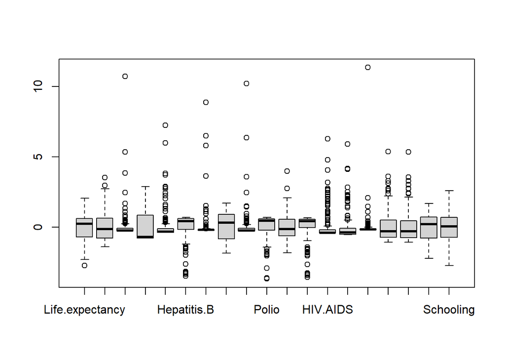

```r
boxplot(scale(data[,3:ncol(data)]))
```

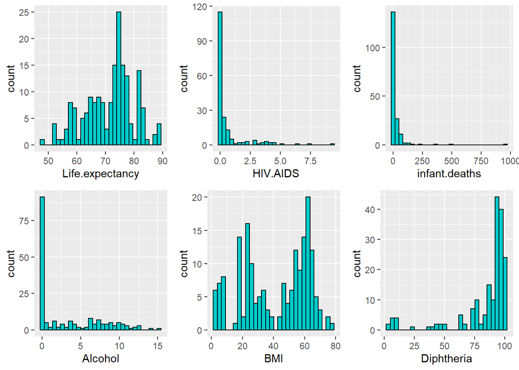

```r
vplayout <- function(x, y) viewport(layout.pos.row = x, layout.pos.col = y)
plot1<-ggplot(data, aes(x=Life.expectancy)) + geom_histogram(color="black", fill='#00cccc')
plot2<-ggplot(data, aes(x=HIV.AIDS)) + geom_histogram(color="black", fill='#00cccc')
plot3<-ggplot(data, aes(x=infant.deaths)) + geom_histogram(color="black", fill='#00cccc')
plot4<-ggplot(data, aes(x=Alcohol)) + geom_histogram(color='black', fill='#00cccc')
plot5<-ggplot(data, aes(x=BMI)) + geom_histogram(color='black', fill='#00cccc')
plot6<-ggplot(data, aes(x=Diphtheria)) + geom_histogram(color='black', fill='#00cccc')

grid.newpage()
pushViewport(viewport(layout = grid.layout(2, 3)))
print(plot1, vp = vplayout(1, 1))
print(plot2, vp = vplayout(1, 2))
print(plot3, vp = vplayout(1, 3))
print(plot4, vp = vplayout(2, 1))
print(plot5, vp = vplayout(2, 2))
print(plot6, vp = vplayout(2, 3))
```

Видно, что в данных имеются выбросы, некоторые данные обладают большим числом нулевых наблюдений, некоторые – атипичными (например, `BMI` и `Diphteria`), далёкими от нормального либо логнормального закона распределениями. Для более качественного анализа, тем не менее, требуется, чтобы данные были близки к нормальному (или логнормальному) закону, поскольку большинство применяемых методов анализа данных подразумевают их нормальность. Это необходимо учитывать при выборе объясняющих переменных.

Теперь необходимо оставить лишь 9 переменных – 8 объясняющих и 1 зависимую, – которые нам потребуются для дальнейшего анализа. Также оставим одну дамми-переменную, которая позволит ориентироваться в данных:

```r
data <- data[, c("Country", "Life.expectancy", "Adult.Mortality",
                    "Alcohol", "Total.expenditure", "Diphtheria",
                    "GDP", "thinness.5.9.years",
                    "thinness..1.19.years", "Schooling")]

# Также упростим названия переменных
names(data) <- c("Country", "Life_exp", "Adult_mort",
                    "Alcohol", "Total_exp", "Dipht",
                    "GDP", "Thinness_5_9", "Thinness_10_19", "Schooling")
```

Наконец, был получен итоговый датасет, показывающий данные по различным странам по 9 информативным показателям за 2014 год. Обработка данных, тем не менее, на этом ещё не окончена: необходимо провести диагностику пропусков.

Дело в том, что в таблице с данными присутствует большое число пропусков, поэтому было решено заполнить эти пропуски данными, найденными на сторонних ресурсах. Поскольку в качестве объясняющих переменных были выбраны `Life.expectancy`,`Adult.Mortality`,`Alcohol`,`Total.expenditure`,`Diphtheria`, `GDP`, `Thinness.5.9.years`, `Thinness..1.19.years`, `Schooling`, то для начала необходимо в целом изучить, какова ситуация с пропусками наблюдений по этим признакам:

```r
d_names <- names(data[,2:ncol(data)])
for (i in d_names) {
  print(i, quote = FALSE)
  print(which(is.na((data[i]))))
}
```

```
[1] Life_exp
integer(0)
[1] Adult_mort
integer(0)
[1] Alcohol
[1] 151
[1] Total_exp
[1]  45 149
[1] Dipht
integer(0)
[1] GDP
 [1]  11  20  28  39  44  45  46  51  54  61  77  89  90  95 107 131 132 136 137
[20] 146 159 162 173 174 175 179 180 181
[1] Thinness_5_9
[1] 151 154
[1] Thinness_10_19
[1] 151 154
[1] Schooling
 [1]  28  44  45  46 131 132 149 173 174 175
```

Как видим, есть пропуски по переменным `Alcohol`, `Total_exp`, `Thinness_10_19`, `Thinness_5_9`, а также особенно много пропусков по `Schooling` и `GDP`. Благо их довольно легко заполнить, найдя информацию на сторонних ресурсах.

Данных по потреблению алкоголя в Южном Судане нет почти нигде, но, учитывая, что эта страна совсем недавно обрела независимость от Судана и по прочим показателям не особенно отличается от этой страны, а также то, что Южный Судан ещё не сильно христианизирован (в исламских странах, как известно, по религиозным соображениям потребление алкоголя, как правило, значительно ниже), то мы дополним это значение тем же, что значится для Судана. В пользу этого также говорит и то, что потребление алкоголя в Центральной Африке довольно низкое (по сравнению, например, с югом континента):

```r
data$Alcohol[151] <- 0.01
```

Далее дополним `Total_exp` в соответствии с данными на сайте http://data.un.org/Data.aspx?d=WHO&f=MEASURE_CODE%3AWHS7_113:

```r
data$Total_exp[45] <- 6.1 # КНДР
data$Total_exp[149] <- 4.3 # Сомали
```

Данные по ВВП найти совсем несложно, хотя пропусков придётся заполнить немало. Однако в процессе заполнения пропусков было выяснено, что исходные данные содержат большие неточности: например, ВВП на душу населения в Болгарии намного выше, чем в Германии или в Канаде. При всём уважении к Болгарии, такое вряд ли возможно:

```r
print(c("ВВП Болгарии:", data$GDP[which(data$Country == "Bulgaria")]), quote=FALSE)
```

```
## [1] ВВП Болгарии: 7853.335191
```

```r
print(c("ВВП Германии:", data$GDP[which(data$Country == "Germany")]), quote=FALSE)
```

```
## [1] ВВП Германии: 4792.65288
```

```r
print(c("ВВП Канады:", data$GDP[which(data$Country == "Canada")]), quote=FALSE)
```

```
## [1] ВВП Канады: 544.43376
```

Скорее всего, имело место уменьшение некоторых значений на целый порядок, следовательно, работать с такими данными бесполезно – они ложные. Поэтому было решено найти новые данные по ВВП по всем странам за 2014 год на сайте https://data.worldbank.org/indicator/NY.GDP.PCAP.CD?view=map&year=2014, затем выбрать те 183 страны, которые и так есть в исходном датасете, и просто заменить нужные колонки:

```r
gdp_da <- read.csv("gdp_data.csv", sep = ",", header = FALSE)
gdp <- gdp_da[,1:ncol(gdp_da)]
data$GDP <- gdp$V6
```

Пропуски по `Thinness_5_9` были заполнены по данным сайта https://www.who.int/data/maternal-newborn-child-adolescent-ageing/indicator-explorer-new/mca для Судана и Южного Судана (оценочные значения ввиду отсутствия данных):

```r
data$Thinness_5_9[151] <- 7.3
data$Thinness_5_9[154] <- 7.6
```

Там же для этих же стран найдены пропуски по `Thinness_10_19`

```r
data$Thinness_10_19[151] <- 7.8
data$Thinness_10_19[154] <- 7.9
```

И, наконец, с помошью того же сайта, что указан выше, заполним пропуски по `Schooling`:

```r
data$Schooling[28] <- 5.4
data$Schooling[44] <- 12.5
data$Schooling[45] <- 7.8
data$Schooling[46] <- 6.7
data$Schooling[131] <- 12.5
data$Schooling[132] <- 10.0
data$Schooling[149] <- 4.7
data$Schooling[173] <- 11.8
data$Schooling[174] <- 5.8
data$Schooling[175] <- 12.9
```

Напоследок ещё раз выведем парочку гистограмм и ящик с усами по обновлённым переменным, которые теперь не содержат пропусков и имеют более чёткий и структурированный вид. Заметно, что обновлённые гистограммы уже по большей части напоминают гистограммы данных, гипотетически подчиняющихся нормальному и логнормальному закону распределения (хотя и заметна асимметрия):

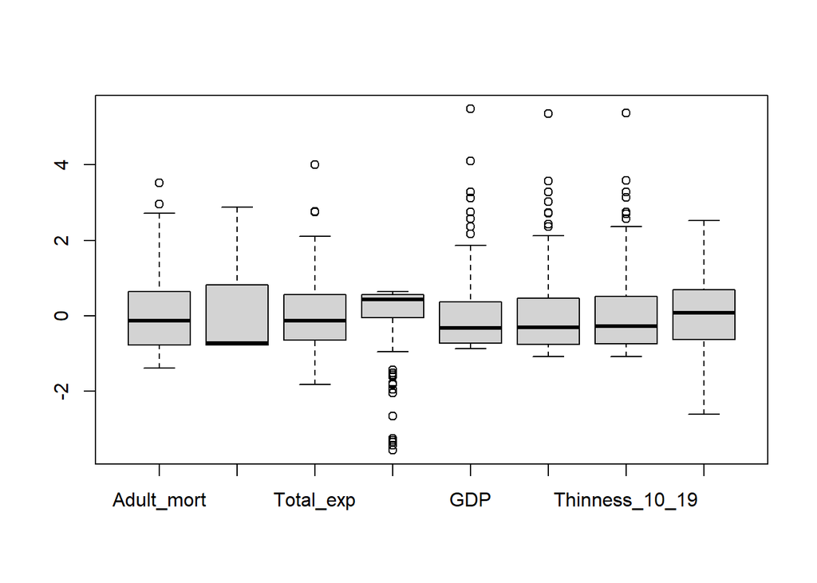

```r
boxplot(scale(data[,3:ncol(data)]))
```

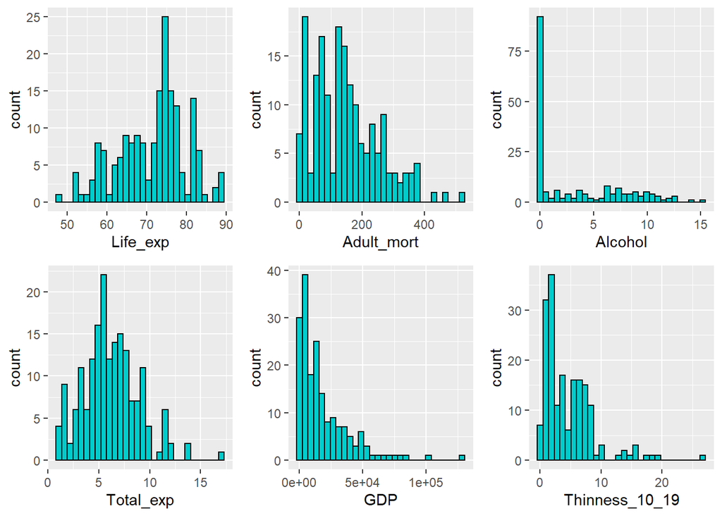

```r
vplayout <- function(x, y) viewport(layout.pos.row = x, layout.pos.col = y)
plot1<-ggplot(data, aes(x=Life_exp)) + geom_histogram(color="black", fill='#00cccc')
plot2<-ggplot(data, aes(x=Adult_mort)) + geom_histogram(color="black", fill='#00cccc')
plot3<-ggplot(data, aes(x=Alcohol)) + geom_histogram(color="black", fill='#00cccc')
plot4<-ggplot(data, aes(x=Total_exp)) + geom_histogram(color='black', fill='#00cccc')
plot5<-ggplot(data, aes(x=GDP)) + geom_histogram(color='black', fill='#00cccc')
plot6<-ggplot(data, aes(x=Thinness_10_19)) + geom_histogram(color='black', fill='#00cccc')

grid.newpage()
pushViewport(viewport(layout = grid.layout(2, 3)))
print(plot1, vp = vplayout(1, 1))
print(plot2, vp = vplayout(1, 2))
print(plot3, vp = vplayout(1, 3))
print(plot4, vp = vplayout(2, 1))
print(plot5, vp = vplayout(2, 2))
print(plot6, vp = vplayout(2, 3))
```

## **1.2 Выдвижение рабочих гипотез исследования Нашим предположением по работе (гипотезой) является то, что все выбранные нами переменные с высокой долей вероятности объясняют зависимую переменную life expectancy. В нашей работе до начала исследований мы выдвинули ряд гипотез. Во-первых, мы выдвинули предположение о зависимой переменной, что она подчиняется нормальному закону распределения. Во-вторых, мы предполагаем, что существует тесная связь между зависимой переменной продолжительностью жизни и объясняющими переменными. В-третьих, мы предполагаем, что, наверное, зависимая переменная будет сильнее всего меняться при изменении GDP И Schooling и total expenditure т.к. это три основных показателя развитости страны, а очевидно, что чем более развитая страна, тем выше по идее должна быть продолжительность жизни. В-четвертых, разные переменные будут в разномнаправлении коррелировать с зависимой переменной.

## **2. Оценка основных характеристик СВ**

В качестве зависимой переменной была выбрана продолжительность жизни. Далее будут рассмотрены статистические характеристики этой величины. Наиболее простой способ их изучить –- воспользоваться функцией `Desc()` из пакета `DescTools`, которая показывает почти все характеристики случайной величины, а также гистограмму распределения, ядерную оценку плотности, ящик с усами и огиву:

```r
y <- data$Life_exp
Desc(y)
```

```
------------------------------------------------------------------------------
y (numeric)

  length       n    NAs  unique     0s   mean  meanCI'
     183     183      0     127      0  71.54   70.29
          100.0%   0.0%           0.0%          72.79

     .05     .10    .25  median    .75    .90     .95
   56.79   59.12  65.60   73.60  76.85  82.16   83.00

   range      sd  vcoef     mad    IQR   skew    kurt
   40.90    8.56   0.12    8.01  11.25  -0.37   -0.38

lowest : 48.1, 51.7, 52.1, 52.6, 52.8
highest: 83.5, 84.0, 87.0, 88.0, 89.0 (4)

' 95%-CI (classic)
```

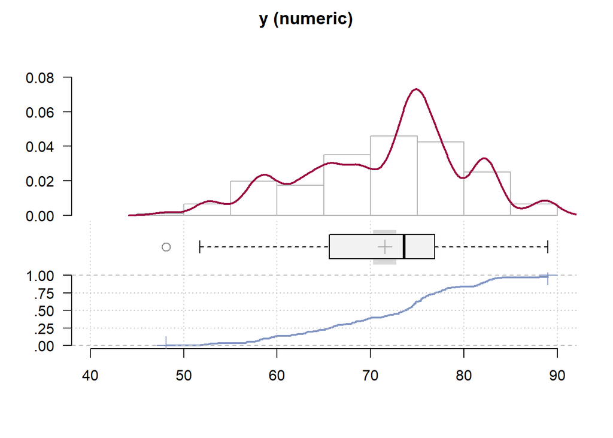

Визуальный анализ показывает, что данные очень слабо напоминают нормальное распределение. Ядерная оценка плотности, как видно, очень далека от идеального Гауссовского колокольчика. Тем не менее, известно, что параметр `aes` при вызове `Desc()` может искажать вид нетипичных данных, поэтому все графики будут построены вручную для более качественного анализа.

Пока же перейдём к рассмотрению характеристик случайной величины `y`.

##### **2.1 Характеристики положения СВ**

При вызове `Desc(y)` были получены значения некоторых выборочных характеристик центра положения, в частности, известно, что $\bar{y}=71.536612$, $Me_y^*=73.6$. Необходимо также найти моду. Поскольку мода в случае непрерывных данных строится по интервальному ряду, будет проведено независимое вычисление моды вручную и сопоставление с тем результатом, что был получен функцией в R:

```r
# Вычисление моды функцией R:
Mode(y)
```

```
[1] 75.4
```

```r
# Вычисление моды вручную
R <- max(y) - min(y) # Размах выборки
h <- R / (1 + log2(183)) # Ширина интервала
a <- min(y) - (h/2)
upper_bound <- seq(from = a + h, to =  a + 10*h, by = h)
# Проверка, что количество интервалов оптимально - должно быть выведено 'TRUE':
(upper_bound[9] < max(y)) & (upper_bound[10] >= max(y))
```

```
[1] TRUE
```

```r
fr1 <- 0
fr2 <- 0
fr3 <- 0
fr4 <- 0
fr5 <- 0
fr6 <- 0
fr7 <- 0
fr8 <- 0
fr9 <- 0
fr10 <- 0

for (i in y) {
  if (i < upper_bound[1]) {
    fr1 <- fr1 + 1
  } else if ((i > upper_bound[1]) & (i < upper_bound[2])) {
    fr2 <- fr2 + 1
  } else if ((i > upper_bound[2]) & (i < upper_bound[3])) {
    fr3 <- fr3 + 1
  } else if ((i > upper_bound[3]) & (i < upper_bound[4])) {
    fr4 <- fr4 + 1
  } else if ((i > upper_bound[4]) & (i < upper_bound[5])) {
    fr5 <- fr5 + 1
  } else if ((i > upper_bound[5]) & (i < upper_bound[6])) {
    fr6 <- fr6 + 1
  } else if ((i > upper_bound[6]) & (i < upper_bound[7])) {
    fr7 <- fr7 + 1
  } else if ((i > upper_bound[7]) & (i < upper_bound[8])) {
    fr8 <- fr8 + 1
  } else if ((i > upper_bound[8]) & (i < upper_bound[9])) {
    fr9 <- fr9 + 1
  } else if ((i > upper_bound[9]) & (i < upper_bound[10])) {
    fr10 <- fr10 + 1
  }
}

frequencies <- c(fr1, fr2, fr3, fr4, fr5, fr6, fr7, fr8, fr9, fr10)
Mode_y <- upper_bound[6] + (h * ((frequencies[7] - frequencies[6]) / (2 * frequencies[7] - frequencies[6] - frequencies[8])))

Mode_y
```

```
[1] 76.2854
```

Мода, посчитанная вручную, как видно, отличается от той, что была дана функцией `Mode()`.

Также, поскольку мимоходом были получены интервалы по формуле Стёрждесса, построим также гистограмму и ядерную оценку плотности. Левосторонняя асимметрия теперь ещё заметнее, но, по крайней мере, ядерная оценка плотности более-менее сглаженная:

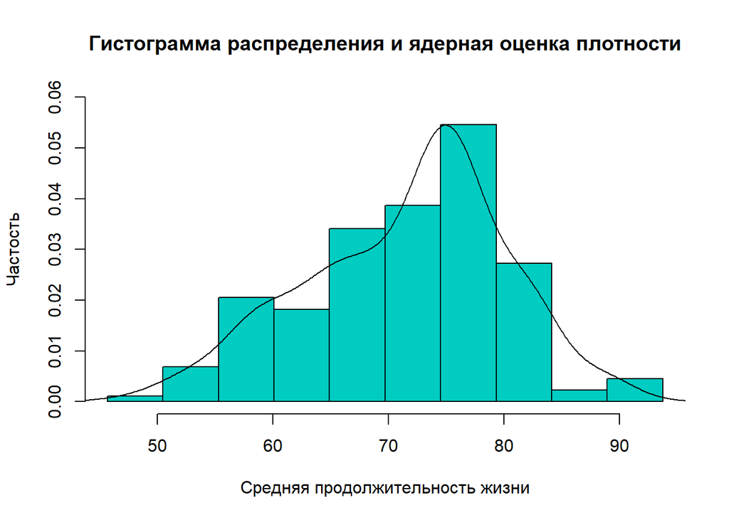

```r
hist(y, breaks = seq(from = a, to =  a + 10*h, by = h),
     col = '#00ccc2',
     main = 'Гистограмма распределения и ядерная оценка плотности',
     xlab = 'Средняя продолжительность жизни',
     ylab = 'Частость', freq = FALSE,
     ylim = c(0, 0.06))

kde <- density(y)
lines(kde)
```

В целом, видно, что, во-первых, характеристики центра отличаются друг от друга, но не сильно. Мода и медиана: $Mo_y^*=76.2854017$, $Me_y^*=73.6$ – отличаются примерно на 3 единицы измерения, если ориентироваться на значение, полученное вручную, и 2 единицы – если смотреть значение, рассчитанное автоматически. Выборочное матожидание $\bar{y}=71.536612$ (относительно общего диапазона) отличается в меньшую сторону. Это, во-первых, говорит о том, что, поскольку $\bar{y} < Me_y$, выборка обладает левосторонней асимметрией, во-вторых, поскольку для нормального закона свойственно то, что характеристики центра – мода, медиана и матожидание – примерно равны друг другу, то имеющееся распределение данных, будучи асимметричным, не вписывается в эту парадигму. Впрочем, более детальную картину можно получить при анализе других рядов характеристик, например, коэффициента асимметрии.

##### **2.2 Характеристики разброса СВ**

Все необходимые, кроме некоторых, характеристики уже получены функцией `Desc()`. Дополним их:

```r
print('Уточнение значения выборочной дисперсии:', quote=FALSE)
```

```
[1] Уточнение значения выборочной дисперсии:
```

```r
var(y)
```

```
[1] 73.28783
```

```r
print('Пределы вырьирования значения выборки:', quote=FALSE)
```

```
[1] Пределы вырьирования значения выборки:
```

```r
range(y)
```

```
[1] 48.1 89.0
```

```r
print('Размах вариации:', quote=FALSE)
```

```
[1] Размах вариации:
```

```r
max(y) - min(y)
```

```
[1] 40.9
```

```r
print('Коэффициент вариации:', quote=FALSE)
```

```
[1] Коэффициент вариации:
```

```r
cv(y)
```

```
[1] 0.1196706
```

```r
print('Квартильное отклонение:', quote=FALSE)
```

```
[1] Квартильное отклонение:
```

```r
IQR(y)/2
```

```
[1] 5.625
```

```r
print('Две трети выборочной дисперсии:', quote=FALSE)
```

```
[1] Две трети выборочной дисперсии:
```

```r
sd(y)*(2/3)
```

```
[1] 5.707221
```

Как видно, минимальным значением в выборке является 48.1, максимальным – 89.

Выборочная дисперсия и среднее квадратическое отклонение характеризуют степень разброса значений случайной величины вокруг её среднего значения. В терминах тех данных, что анализируются настоящим расчётом, эти характеристики показывают степень разброса значений продолжительности жизни для исследуемых 183 стран. Выборочная (исправленная) дисперсия $s^2=73.287828$, выборочное СКО $s=8.56$ – довольно небольшое относительно выборки, в принципе, можно сказать – и визуальный анализ это подтверждает, – что значения сконцентрированы примерно около выборочного среднего. Неустойчивый к выбросам коэффициент вариации, показывающий меру рассеяния исседуемого признака, $V_s=11.9670625 \% <33\%$, следовательно, выборку можно охарактеризовать как однородную. Относительный показатель квартильной вариации имеет следующее значение:

```r
(IQR(y)/(2 * median(y)))*100
```

```
[1] 7.642663
```

Это значение является аналогом коэффициента вариации, который, поскольку содержит в формуле выборочное среднее, гораздо менее устойчив к выбросам. И хотя $V_s$ и так показывал довольно низкий процент вариации, уточнение с помошью относительного показателя интерквартильной вариации дало значение $K_Q = 7.64\%$, что окончательно позволяет сделать вывод о том, что выборка однородная.

Более того, исследованные характеристики разброса позволяют сделать вывод, что либо в выборке совсем не содержится выбросов, либо их мало и они незначительно отличаются от общепринятых метрик, например, от $3IQR$. Подтвердить эти гипотезы можно будет при диагностике выбросов.

Также рассмотрим в этой части коэффициенты эксцесса и асимметрии, полученные функцией `Desc(y)`. Коэффициент асимметрии $Ac^* = -0.37$, что показывает, что, во-первых, поскольку $sign(Ac^*) = −1$, имеет место левосторонняя асимметрия, во-вторых, несмотря на то, что $ |Ac^*|< 0.5$, коэффициент асимметрии довольно близок по своему значению к пороговому, следовательно, следует говорить о достаточной асимметрии гистограммы (и именно это показывало построение графических интерпретаций имеющихся данных).

Коэффициент эксцесса $Ek^* = -0.38$, что показывает следующее: во-первых, так как $Ek^*<0$ и $|Ek^*|<0.5$ (хоть и близок к этому значению), график распределения имеет более плоскую вершину относительно графика плотности нормального распределения.

##### **2.3 Ранговые характеристики СВ**

Уже посчитано, что разброс $R = 40.9$. Получим более понятные данные:

```r
summary(y)
```

```
   Min. 1st Qu.  Median    Mean 3rd Qu.    Max.
  48.10   65.60   73.60   71.54   76.85   89.00
```

Как видно, $y_{min}=48.1$, $Me=y_{0.5}=73.6$, $y_{0.75}=76.85$, при этом максимальное значение в выборке $y_{max} = 89$, что незначительно (на $15\%$) больше $75\%$ значений выборки. Значит, опять-таки, скорее всего, в выборке нет существенных выбросов.

Можно также посчитать, во сколько раз продолжительность жизни в 10% стран с самым высоким уровнем этого показателя больше продолжительности жизни в $10\%$ наименее благополучных в этом плане стран:

```r
kf <- quantile(y, probs = seq(0, 1, 0.1))[10]/quantile(y, probs = seq(0, 1, 0.1))[2]
names(kf) <- 'Во сколько раз продолжительность жизни в 10% стран с самым высоким уровнем этого показателя больше продолжительности жизни в 10% наименее благополучных в этом плане стран:'
kf
```

```
Во сколько раз продолжительность жизни в 10% стран с самым высоким уровнем этого показателя больше продолжительности жизни в 10% наименее благополучных в этом плане стран:
                                                                                                                                                                   1.389716
```

Несущественное отличие, впрочем, если речь идёт о продолжительности жизни, тут вряд ли стоило ожидать существенного разброса: всё-таки человечий век ограничен.

Итак, суммируя все выкладки, можно сделать следующее краткое заключение: выборка – и это связано со спецификой обрабатываемых данных, а именно – возраста человека, который ограничен по значению – однородна, имеет мало (или совсем не имеет) выбросов, значения внутри выборки не сильно варьируются. Распределение имеет левостороннюю асимметрию, что означает, что средние значения продолжительности жизни (интервал примерно в 11 лет) сконцентрированы – об этом же свидетельствует значение моды и медианы – около примерно 70+ лет, и это хороший, довольно большой возраст. Значит, в целом человеческая цивилизация успешно добивается увеличения продолжительности жизни, и в дальнейшем будет проанализировано, какие именно факторы влияют на достижение такого результата.

## **3. Диагностика выбросов**

Как было проанализировано ранее, результирующая переменная, скорее всего, либо совсем не имеет выбросов (условно, по метрике 3IQR), либо имеет их очень мало. Далее необходимо проверить это аналитически, для чего будут проведены различные процедуры диагностики выбросов, более или менее чувствительные и “строгие”.

Приступим к удалению выбросов. Сначала пропишем функции, возвращающие выбросы, определённые по правилу 3 и 1.5 IQR, по входным данным:

```r
IQR3 <- function(y) {
  out_of_3IQR <- boxplot.stats(y, coef = 3)$out
  return(out_of_3IQR)
}

IQR1.5 <- function(y) {
  out_of_1_5IQR <- boxplot.stats(y, coef = 1.5)$out
  return(out_of_1_5IQR)
}
```

Теперь применим их:

```r
IQR3(y)
```

```
numeric(0)
```

```r
IQR1.5(y)
```

```
[1] 48.1
```

Как видно, в соответствии с правилом 3 IQR, согласно которому наблюдение квалифицируется как выброс в том случае, если оно не входит в интервал $(Q_1-3IQR;Q_3+3IQR)$, то есть превосходит значение суммы третьей квартили и добавленному к ней тройному интерквартильному размаху (или, напротив, меньше значения разности $Q_1-3IQR$), в исследуемой выборке выбросов нет совсем. Более “чувствительное” правило 1.5 IQR, по которому интервал вхождения значений гораздо уже, идентифицировало 1 аномальное значение: 48.1.

Можно в целом прикинуть, какой интервал дают эти правила:

```r
quantile(y)
```

```
   0%   25%   50%   75%  100%
48.10 65.60 73.60 76.85 89.00
```

```r
IQR(y)
```

```
[1] 11.25
```

```r
# Правило 3 IQR
65.60-3*IQR(y)
```

```
[1] 31.85
```

```r
76.85+3*IQR(y)
```

```
[1] 110.6
```

```r
# Правило 1.5 IQR
65.60-1.5*IQR(y)
```

```
[1] 48.725
```

```r
76.85+1.5*IQR(y)
```

```
[1] 93.725
```

Видно, что в первом случае интервал $(31.85;110.6)$ гораздо шире, чем во втором: $(48.725;93.725)$.

Теперь воспользуемся правилом 3 сигм, наиболее информативным для нормально распределённых данных (в нашем случае о нормальности говорить рано: недостаточно фактов), которое гласит: вероятность того, что любая случайная величина отклонится от своего среднего значения менее чем на $3 \sigma$, превышает $\dfrac{8}{9}$, то есть практически все значения случайной величины заключены в интервале $(\mu^*-3\sigma;\mu^*+3\sigma)$, где $\mu^*$ – выборочное матожидание:

```r
mean(y)-3*SD(y)
```

```
[1] 45.85412
```

```r
mean(y)+3*SD(y)
```

```
[1] 97.21911
```

```r
sort(y)[1:3]
```

```
[1] 48.1 51.7 52.1
```

```r
sort(y)[179:182]
```

```
[1] 88 89 89 89
```

Не мудрствуя лукаво и просто отсортировав выборку, чтобы посмотреть несколько первых и последних значений, можно убедиться, что с вероятностью $\dfrac{8}{9}$ в выборке нет выбросов. Это, конечно, при условии большого допущения о нормальном законе распределения случайной величины, впрочем, полученный результат эквивалентен тому, что был получен для правила 3 IQR.

Для анализа 8 объясняющих переменных, думается, вполне можно обойтись лишь правилом 3 и 1.5 IQR, поскольку именно он будет в дальнешем задействоваться на других этапах работы:

```r
d_names <- names(data)[2:10]
for (i in d_names) {
  print(i, quote = FALSE)
  print(IQR3(as.matrix(data[i])), quote=FALSE)
}
```

```
[1] Life_exp
numeric(0)
[1] Adult_mort
numeric(0)
[1] Alcohol
numeric(0)
[1] Total_exp
numeric(0)
[1] Dipht
 [1] 37  9  9  8  2  7  9  5  8  9 39  8 23
[1] GDP
[1] 101297.6 129068.9
[1] Thinness_5_9
[1] 27.4
[1] Thinness_10_19
[1] 26.8
[1] Schooling
numeric(0)
```

Наибольшее число выбросов зафиксировано по переменной `Dipht`. По другим переменным имеется 1-2 наблюдение, не входящее в интервал. По правилу 1.5 IQR, разумеется, выбросов должно быть больше:

```r
d_names <- names(data)[2:10]
for (i in d_names) {
  print(i, quote = FALSE)
  print(IQR1.5(as.matrix(data[i])), quote=FALSE)
}
```

```
[1] Life_exp
[1] 48.1
[1] Adult_mort
[1] 522 463
[1] Alcohol
numeric(0)
[1] Total_exp
[1] 13.73 13.71 17.14
[1] Dipht
 [1] 47 37  9  9  8  2  7 51 48  9  5 49  8  9 42 39 43  8 23
[1] GDP
[1]  81373.02  70082.42 101297.58  65892.69 129068.87  84423.19  61902.16
[8]  73619.10
[1] Thinness_5_9
[1] 17.5 18.6 16.2 27.4 16.3 19.8 15.0 14.7
[1] Thinness_10_19
[1] 17.5 18.1 15.7 26.8 15.9 19.4 15.2
[1] Schooling
numeric(0)
```

Что и требовалось показать: добавилось выбросов по переменным `GDP`, `Total_exp` и другим.

Правило $3\sigma$ к этим переменным применять не будем, поскольку это довольно опасно: распределения данных, как было показано, имеют по многим переменным вид, близкий к логнормальному, следовательно, возможно, правило, которое применяется в основном для нормально распределённых данных, будет неуместно.

Визулизиуем выбросы по каждой переменной. Ящик с усами очень хорошо показывает это:

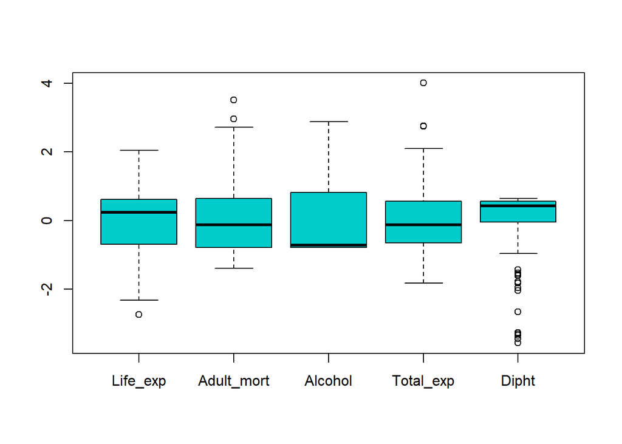

```r
plot1<-boxplot(scale(data[,2:6]),  col = '#00cccc')
```

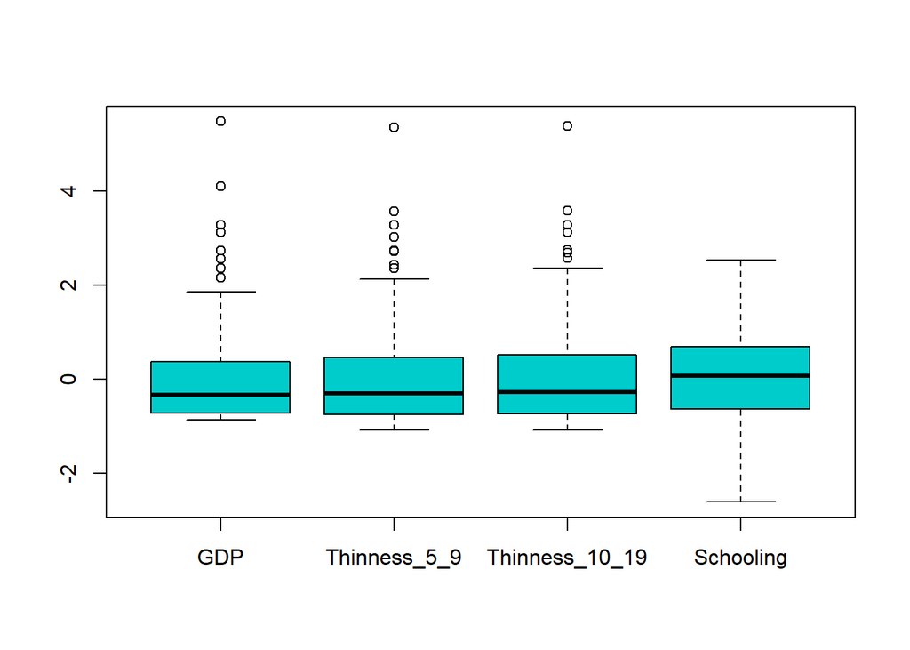

```r
plot2<-boxplot(scale(data[,7:10]),  col = '#00cccc')
```

Было решено отмасштабировать данные, потому что имеются переменные с очень большими относительно других переменных значениями. Видно, что ящичковая диаграмма строит выбросы по правилу 1.5 IQR, и выбросами – как и было ранее показано – обладает существенное число переменных. Однако выборка и так не особенно большая, чтобы удалять данные чрезмерно тщательно, поэтому было решено остановиться именно на 3IQR. Также есть основания полагать, что после логарифмирования части данных удастся стабилизировать дисперсию, и выбросов, возможно, будет меньше. Убедимся в этом, выбрав для начала данные для логарифмирования, что можно осуществить достаточно надёжно, лишь посмотрев на выборочные распределения:

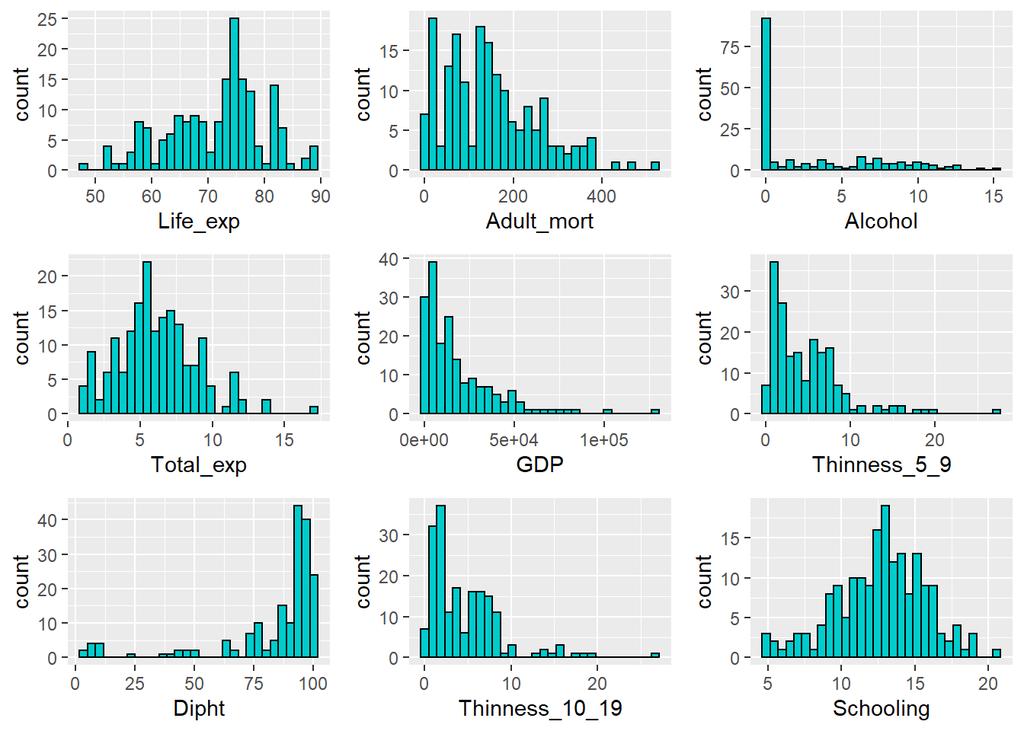

```r
vplayout <- function(x, y) viewport(layout.pos.row = x, layout.pos.col = y)
plot1<-ggplot(data, aes(x=Life_exp)) + geom_histogram(color="black", fill='#00cccc')
plot2<-ggplot(data, aes(x=Adult_mort)) + geom_histogram(color="black", fill='#00cccc')
plot3<-ggplot(data, aes(x=Alcohol)) + geom_histogram(color="black", fill='#00cccc')
plot4<-ggplot(data, aes(x=Total_exp)) + geom_histogram(color='black', fill='#00cccc')
plot5<-ggplot(data, aes(x=GDP)) + geom_histogram(color='black', fill='#00cccc')
plot6<-ggplot(data, aes(x=Thinness_5_9)) + geom_histogram(color='black', fill='#00cccc')
plot7<-ggplot(data, aes(x=Dipht)) + geom_histogram(color='black', fill='#00cccc')
plot8<-ggplot(data, aes(x=Thinness_10_19)) + geom_histogram(color='black', fill='#00cccc')
plot9<-ggplot(data, aes(x=Schooling)) + geom_histogram(color='black', fill='#00cccc')

grid.newpage()
pushViewport(viewport(layout = grid.layout(3, 3)))
print(plot1, vp = vplayout(1, 1))
print(plot2, vp = vplayout(1, 2))
print(plot3, vp = vplayout(1, 3))
print(plot4, vp = vplayout(2, 1))
print(plot5, vp = vplayout(2, 2))
print(plot6, vp = vplayout(2, 3))
print(plot7, vp = vplayout(3, 1))
print(plot8, vp = vplayout(3, 2))
print(plot9, vp = vplayout(3, 3))
```

Судя по гистограммам, есть смысл логарифмировать данные по всем переменным, кроме `Schooling` и `Total_exp`, которые и так имеют квазинормальный вид, и `Dipht`, распределение которой и вовсе атипично. Также в ходе экспериментов было решено не логарифмировать переменные `Adult_mort` и `Alcohol`, поскольку логарифмирование (и даже логарифмирование с линейными преобразованиями, например, домножением на 1000 или 100 для увеличения значения и устранения необходимости работать с отрицательными значениями после логарифмирования) мало помогает в стабилизации дисперсии и выбросов в этих случаях, а распределение после всех преобразований было всё ещё мало похожим на нормальное (p-value меньше всякого разумного уровня значимости), к тому же генерируется чрезвычайно много выбросов.

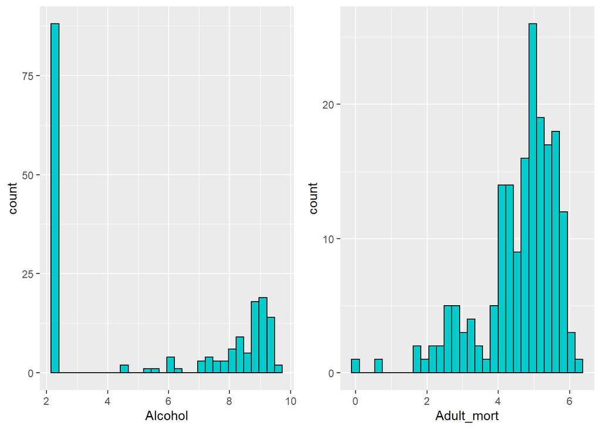

```r
data_ex <- data.frame(data)
data_ex$Adult_mort <- log(data_ex$Adult_mort)
data_ex$Alcohol <- log(data_ex$Alcohol * 1000)
vplayout <- function(x, y) viewport(layout.pos.row = x, layout.pos.col = y)
plot1<-ggplot(data_ex, aes(x=Alcohol)) + geom_histogram(color="black", fill='#00cccc')
plot2<-ggplot(data_ex, aes(x=Adult_mort)) + geom_histogram(color="black", fill='#00cccc')


grid.newpage()
pushViewport(viewport(layout = grid.layout(1, 2)))
print(plot1, vp = vplayout(1, 1))
print(plot2, vp = vplayout(1, 2))
```

Так что преобразование проведём только над некоторыми переменными:

```r
data1 <- data.frame(data)

#data$Adult_mort <- log(data$Adult_mort) -- было решено не логарифмировать
#data1$Alcohol <- log(data$Alcohol) -- было решено не логарифмировать

data1$GDP <- log(data$GDP)
data1$Thinness_5_9 <- log(data1$Thinness_5_9)
data1$Thinness_10_19 <- log(data1$Thinness_10_19)
```

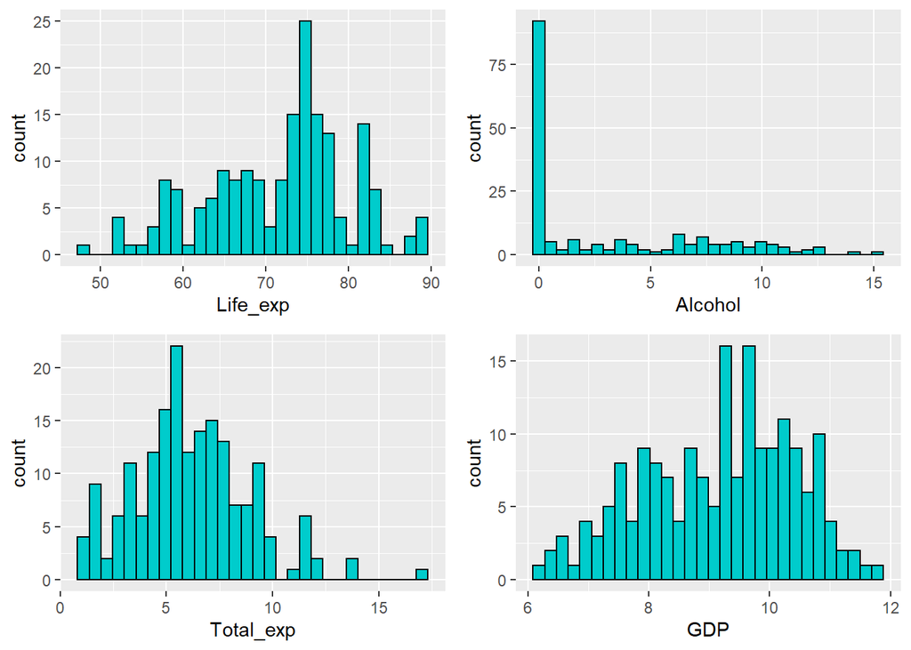

```r
vplayout <- function(x, y) viewport(layout.pos.row = x, layout.pos.col = y)
plot1<-ggplot(data1, aes(x=Life_exp)) + geom_histogram(color="black", fill='#00cccc')
plot2<-ggplot(data1, aes(x=Alcohol)) + geom_histogram(color="black", fill='#00cccc')
plot3<-ggplot(data1, aes(x=Total_exp)) + geom_histogram(color='black', fill='#00cccc')
plot4<-ggplot(data1, aes(x=GDP)) + geom_histogram(color='black', fill='#00cccc')
plot5<-ggplot(data1, aes(x=Thinness_10_19)) + geom_histogram(color='black', fill='#00cccc')
plot6<-ggplot(data1, aes(x=Dipht)) + geom_histogram(color='black', fill='#00cccc')
plot7<-ggplot(data1, aes(x=Thinness_5_9)) + geom_histogram(color='black', fill='#00cccc')
plot8<-ggplot(data1, aes(x=Schooling)) + geom_histogram(color='black', fill='#00cccc')

grid.newpage()
pushViewport(viewport(layout = grid.layout(2, 2)))
print(plot1, vp = vplayout(1, 1))
print(plot2, vp = vplayout(1, 2))
print(plot3, vp = vplayout(2, 1))
print(plot4, vp = vplayout(2, 2))
```

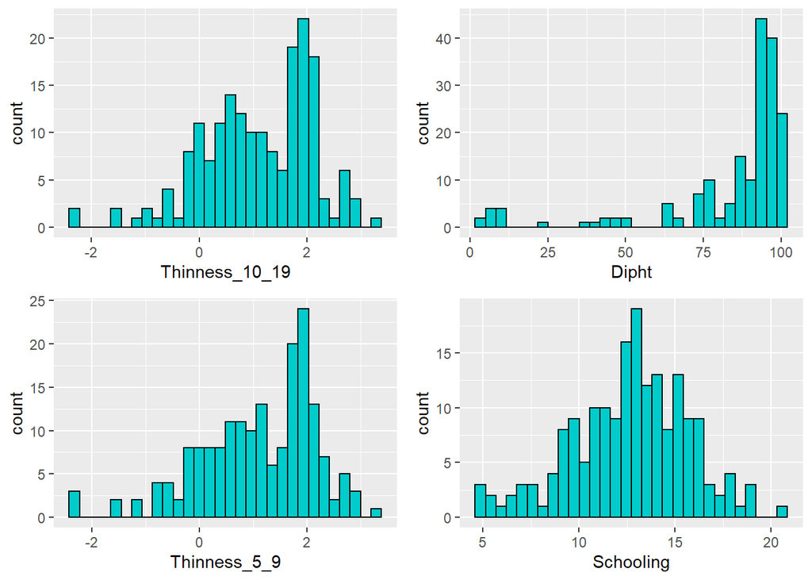

```r
grid.newpage()
pushViewport(viewport(layout = grid.layout(2, 2)))
print(plot5, vp = vplayout(1, 1))
print(plot6, vp = vplayout(1, 2))
print(plot7, vp = vplayout(2, 1))
print(plot8, vp = vplayout(2, 2))
```

По гистограммам видно, что более адекватно стала выглядеть выглядеть переменная `GDP`; у переменных `Thinness_5_9` и `Thinness_10_19` есть некоторый “взрыв” значений в правом хвосте распределения.

Конечно, логарифмирование ударило по дальнейшей интерпретационной силе показателей, зато удалось стабилизировать переменные, что также немаловажно.

Проинспектируем выбросы после преобразований:

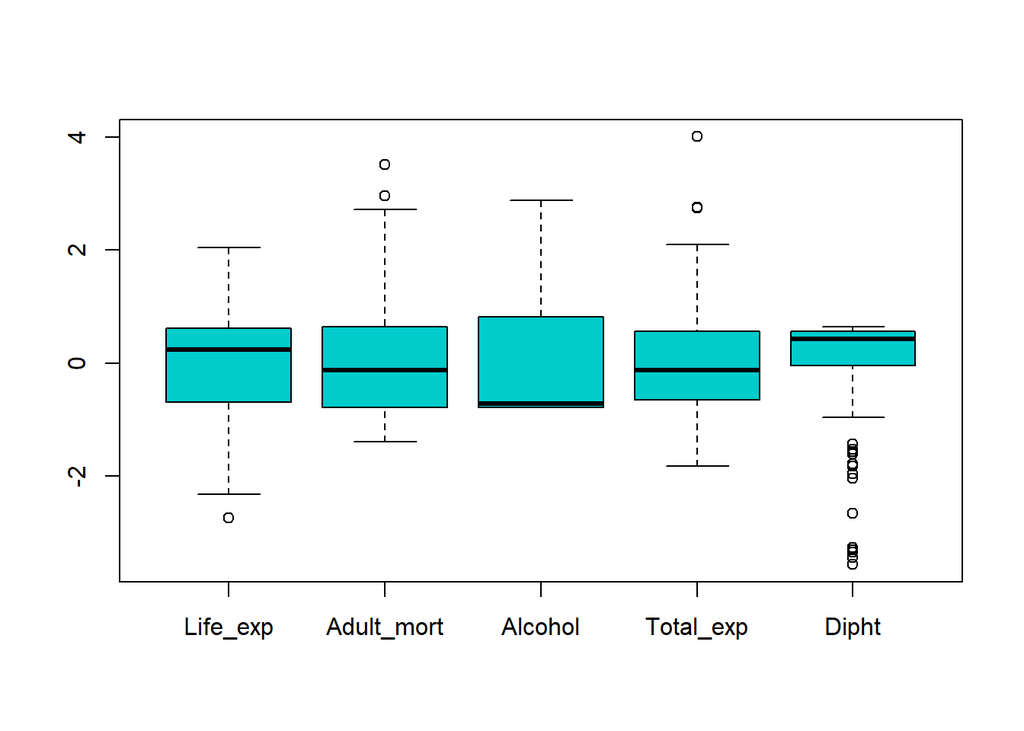

```r
plot1<-boxplot(scale(data1[,2:6]),  col = '#00cccc')
```

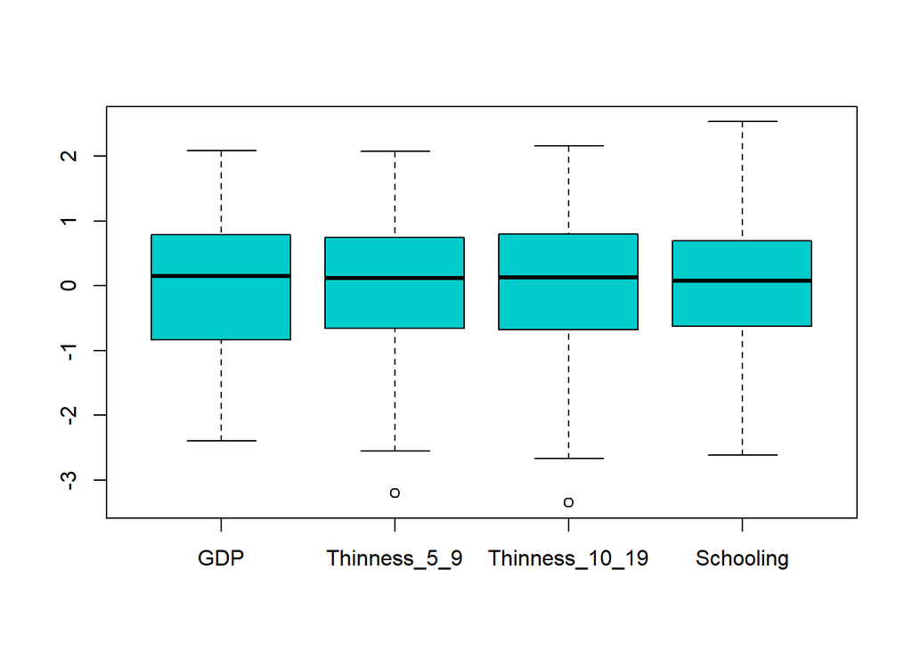

```r
plot2<-boxplot(scale(data1[,7:10]),  col = '#00cccc')
```

Видно, что выбросов стало меньше. Правда, осталось значительное число аномальных наблюдений у тех переменных, которые никак не обрабатывались. Выведем значения выбросов:

```r
d_names <- names(data1)[2:10]
for (i in d_names) {
  print(c(i, ":", IQR3(as.matrix(data1[i]))), quote=FALSE)
}
```

```
[1] Life_exp :
[1] Adult_mort :
[1] Alcohol :
[1] Total_exp :
 [1] Dipht :     37    9     9     8     2     7     9     5     8     9
[13] 39    8     23
[1] GDP :
[1] Thinness_5_9 :
[1] Thinness_10_19 :
[1] Schooling :
```

Выбросов по правилу 3 IQR, как и раньше, гораздо меньше, чем по правилу 1.5 IQR, но после логарифмирования выбросы и вовсе пропали (кроме переменной `Dipht`).

Для диагностики выбросов можно также воспользоваться критериями Граббса и Рознера о наличии аномальных наблюдений. Критерий Граббса выполняет итеративную проверку $H_0$ о том, что одно максимальное или минимальное наблюдение в выборке является типичным наблюдением. В переменной `Life_exp` как раз было выявлено одно экстремальное (по правилу 1.5 IQR) наблюдение. Критерий же Рознера позволяет проверить $k>1$ наблюдение на аномальность. Нулевая гипотеза формулируется в слеюущем виде: $H_0$: {$k$ наибольших наблюдений взяты из той же генеральной совокупности, что и $(n−k)$ первых наблюдений}.

Стоит, однако, учитывать, что оба теста разработаны в предположении нормального распределения генеральной совокупности, из которой взята однородная выборка, следовательно, использовать эти тесты нужно осторожно. Обратимся к уже выведенным гистограммам по всем переменным и оценим примерные распределения данных.

Как видно, ряд данных (и, главное, результирующая переменная) имеют распределение, внешне близкое к нормальному, но часть переменных далеки по своему виду от Гауссовской кривой (например, всё та же `Dispht`). Имея это в виду, проведём тест:

```r
grubbs.test(y, type = 10, opposite = FALSE, two.sided = FALSE)
```

```
    Grubbs test for one outlier

data:  y
G = 2.73766, U = 0.95859, p-value = 0.5244
alternative hypothesis: lowest value 48.1 is an outlier
```

Как видно, p-value = 0.5244, соответственно, на довольно высоком уровне значимости можно утверждать, что гипотеза о типичности наблюдения в левом хвосте не отвергается. К слову, если выставить `type = 11`, что будет равносильно проверке о том, что оба наблюдения в обоих хвостах являются типичными, то p-value в этом случае достигает 1. То есть можно заключить, что – при условии нормального распределения переменной `data$Live_exp$ – выбросов по этой переменной нет.

Теперь проведём тест Рознера. Сразу выведем тот подмассив результатов, который нам нужен. Параметр $k$ можно было бы выставить равным 1, потому что многие предыдущие методы выявляли лишь это наблюдение в качества выброса, но в итоге было решено взять стандартное значение. И, что и требовалось показать, очередной тест указывает на то, что в выборке нет выбросов – при условии, что выборка взята из нормальной ГС.

```r
rosnerTest(y, k = 3, alpha = 0.05)$all.stats
```

| i | Mean.i | SD.i | Value | Obs.Num | R.i+1 | lambda.i+1 | Outlier |
| --- | --- | --- | --- | --- | --- | --- | --- |
| 0 | 71.53661 | 8.560831 | 48.1 | 144 | 2.737656 | 3.578653 | FALSE |
| 1 | 71.66538 | 8.404843 | 51.7 | 4 | 2.375462 | 3.576983 | FALSE |
| 2 | 71.77569 | 8.295003 | 52.1 | 93 | 2.371993 | 3.575301 | FALSE |

И, чтобы не забивать пространство работы, объясняющие переменные не будут подвергаться такому тестированию – во-первых, потому что распределения этих переменных в большинстве случаев явно не нормальные, во-вторых, потому что уже была сделана диагностика по правилу 3 IQR, которая, как видно по `data$Life_exp$, принесла те же результаты, что и эти тесты.

В целом, можно сказать, что данные довольно удачные в плане выбросов: по правилу 3 IQR их нет вообще (за исключением одной переменной), по правилу 1.5 IQR имеются некоторые аномальные значения. Результирующая переменная в силу своей специфики (она обозначает средний возраст, грубо говоря) вполне ожидаемо не имела выбросов (это было показано большинством проведённых тестов).

## **4. Проверка соответствия эмпирического распределения нормальному закону**

В предыдущих частях работы уже обсуждались численные характеристики коэффициентов асимметрии и эксцесса для результирующей переменной и был сделан вывод, что они свидетельствуют о несущественной левосторонней асимметрии и некоторой плосковершинности относительно кривой Гаусса, а примерного равенства выборочных моды, медианы и среднего, свойственного нормальному закону распределения, у исследуемой зависимой переменной нет. Так что есть основания сомневаться в нормальности распределения этой переменной.

Далее на этом этапе проанализировать графические визуализации переменной. Начнём с гистограммы плотности с нанесённой поверх теоретической кривой Гаусса:

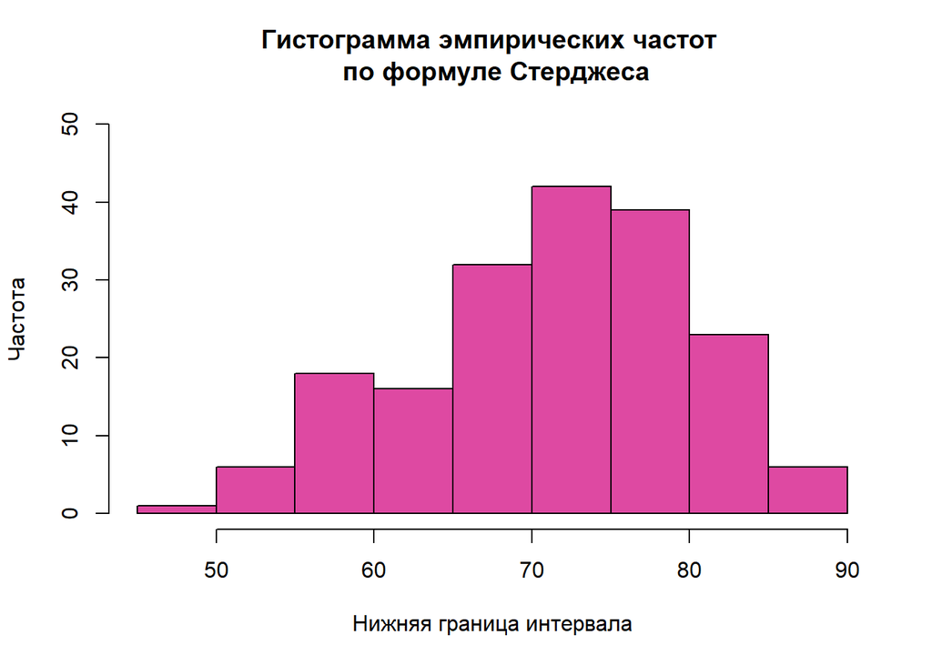

```r
hist_2 = hist(y, freq = TRUE, col = '#de49a2',
            breaks = 'sturges', xlab = 'Нижняя граница интервала',
            ylab = 'Частота',
            ylim = c(0, 50),
            main = 'Гистограмма эмпирических частот \n по формуле Стерджеса')
```

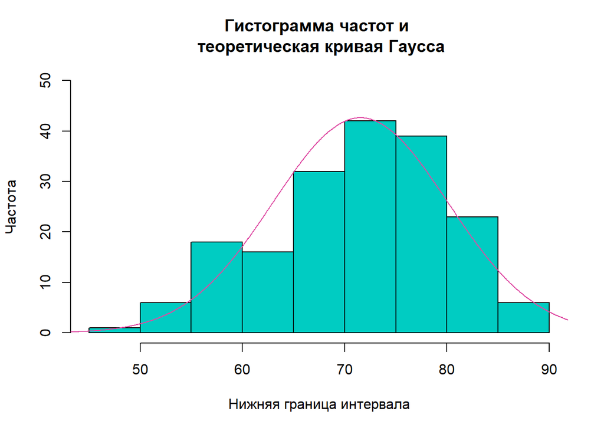

```r
x_vals <- seq(from = min(y) - 10,to = max(y) + 10,length = 1000)

hh = unlist(hist_2['breaks'])[2] - unlist(hist_2['breaks'])[1]
y_vals <- dnorm(x_vals, mean = mean(y), sd = sd(y))*hh*183

hist_5 = hist(y, freq = TRUE, col = '#00ccc2', breaks = 'sturges', xlab = 'Нижняя граница интервала', ylab = 'Частота', ylim = c(0, 50), main = 'Гистограмма частот и \n теоретическая кривая Гаусса')
lines(x_vals, y_vals, col = '#de49a2')
```

Видно всё то, что описывалось ранее: асимметрия и плосковершинность. Также заметно, что результирующая переменная неплохо приближается теоретической кривой Гаусса, хотя и не идеально.

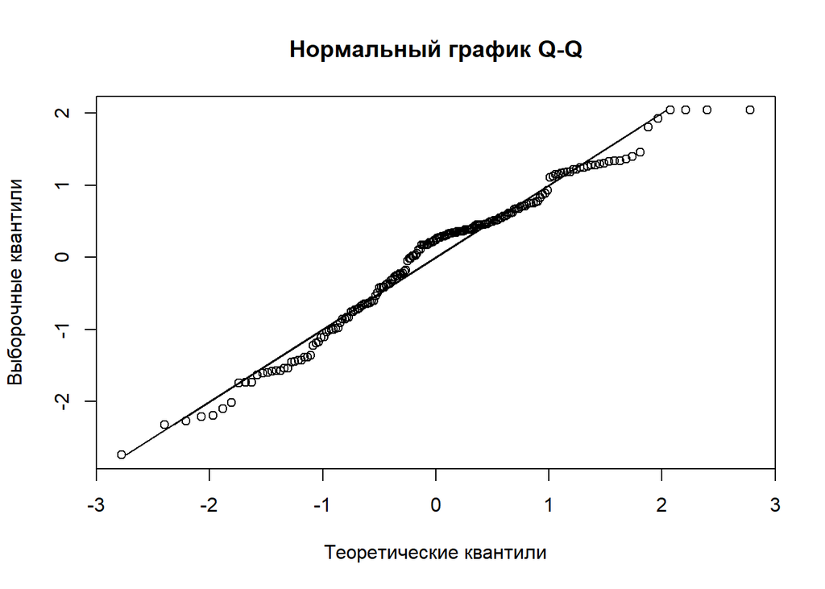

```r
qqnorm(scale(y), main = 'Нормальный график Q-Q',
       xlab = 'Теоретические квантили', ylab = 'Выборочные квантили')
lines(scale(y), scale(y), type = 'l')
```

Как видно, данные группируются вдоль кривой не очень хорошо, имеется много отклонений. Местами точки эмпирического распределения близки к прямой под углом 45 градусов на графике, что говорило бы в пользу нормальности распределения, однако есть области, где скачки и расхождения серьёзны.

Построим также диаграмму “стебель-листья”, которая тоже позволяет визуально оценить распределение:

```r
stem(y, scale = 1)
```

```
  The decimal point is at the |

  48 | 1
  50 | 7
  52 | 1686
  54 | 3
  56 | 677689
  58 | 011441233779
  60 | 145
  62 | 017900128
  64 | 22441134579
  66 | 001244039
  68 | 000344892446679
  70 | 0144778
  72 | 0450000133456899
  74 | 0012344555666678888013444445568899
  76 | 0224468892335668
  78 | 000126015
  80 | 02445677
  82 | 00223556790025
  84 | 0
  86 | 0
  88 | 00000
```

… и график dot plot, который также позволяет оценить плотность распределения:

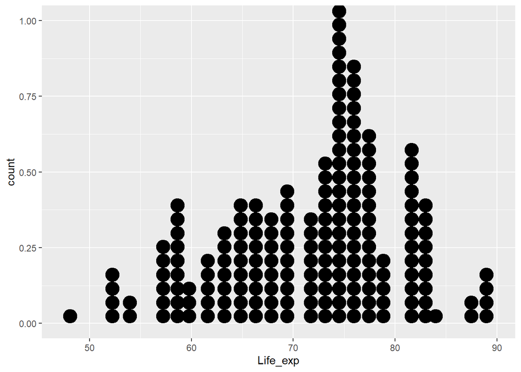

```r
ggplot(data1, aes(x = Life_exp)) + geom_dotplot() + ylim(0, 1)
```

В обоих случаях видно, что данные, в принципе, похожи на кривую Гаусса.

Итого, графические методы показали, что распределение данных с натяжкой можно считать похожими на нормальное, хотя результат разнится от метода к методу. Перейдём к более надёжному методу проверки нормальности: тестам на нормальность.

Начать стоит с наиболее мощного критерия провекри на нормальность: критерия Шапиро-Уилка

```r
shapiroTest(y, title = NULL, description = NULL)
```

```
Title:
 Shapiro - Wilk Normality Test

Test Results:
  STATISTIC:
    W: 0.9748
  P VALUE:
    0.00213

Description:
 Fri Apr 16 23:12:50 2021 by user: Asus
```

Значение p-value = 0.00213 меньше многих разумных уровней значимости, самым оптимистичным выводом было бы не отвергать гипотезу о нормальности на уровне значимости $\alpha = 0.001$ согласно тесту Шапиро-Уилка. Впрочем, нужно иметь в виду, что тест Шапиро-Уилка рекомендован для малых выборок (из-за своей чувствительности), а при больших объемах выборки имеет ограничения в применении, для чего была предложена его модификация – критерий Шапиро-Франчиа (Shapiro-Francia SF test). и хотя 183 наблюдения – это по-прежнему маленький объём выборки, и вряд ли он годится для серьёзных аппроксимационных алгоритмов, которые могут исказить картину, всё-таки 183>100 (для такого объема обычно рекомендуется критерий Шапиро-Уилка), поэтому можно также воспользоваться модификацией критерия Шапиро-Уилка – критерием Шапиро-Франчиа (Shapiro-Francia SF test):

```r
sf.test(y)
```

```
    Shapiro-Francia normality test

data:  y
W = 0.97684, p-value = 0.005046
```

p-value, как видно, стал больше, хоть и не намного. Теперь гипотезу о нормальности можно не отвергать на весьма разумном уровне значимости $\alpha=0.005$, что, конечно, всё ещё мало.

Конечно, можно проверить и не такие сильные тесты: например, с помощью критерия Пирсона или критерия Колмогорова, но, поскольку эти тесты очень маломощные, будем использовать их модификации: например, модификацию теста Колмогорова-Смирнова – тест Лиллиефорса:

```r
lillie.test(y)
```

```
    Lilliefors (Kolmogorov-Smirnov) normality test

data:  y
D = 0.11978, p-value = 1.004e-06
```

```r
pearson.test(y)
```

```
    Pearson chi-square normality test

data:  y
P = 36.142, p-value = 0.0009935
```

Как видно, p-value получилось очень маленьким для обоих тестов – меньше, чем в случае более надёжных тестов, следовательно, нет особого смысла и значимости принимать эти результаты всерьёз. Также из интереса посмотрим распределения объясняющих переменных:

```r
d_names <- names(data1)[2:10]
for (i in d_names) {
  print(i)
  print(sf.test(as.matrix(data1[i])))
}
```

```
[1] "Life_exp"

Results of Hypothesis Test
--------------------------

Alternative Hypothesis:

Test Name:                       Shapiro-Francia normality test

Data:                            as.matrix(data1[i])

Test Statistic:                  W = 0.9768437

P-value:                         0.005045842

[1] "Adult_mort"

Results of Hypothesis Test
--------------------------

Alternative Hypothesis:

Test Name:                       Shapiro-Francia normality test

Data:                            as.matrix(data1[i])

Test Statistic:                  W = 0.9444863

P-value:                         6.207802e-06

[1] "Alcohol"

Results of Hypothesis Test
--------------------------

Alternative Hypothesis:

Test Name:                       Shapiro-Francia normality test

Data:                            as.matrix(data1[i])
```

[output cut: 79 more lines]

```

[1] "Schooling"

Results of Hypothesis Test
--------------------------

Alternative Hypothesis:

Test Name:                       Shapiro-Francia normality test

Data:                            as.matrix(data1[i])

Test Statistic:                  W = 0.9902369

P-value:                         0.2126697
```

Как видно, чрезвычайно высоким относительно других p-value обладает переменная `Schooling`. Также относительно неплохие результаты у тех переменных, что были прологарифмированы. Очевидно сильное отклонение от нормального закона имеют `Alcohol`, `Dipht` и `Adult_mort` – то, что мы и предполагали ранее.

Итак, имеющуюся результирующую переменную можно с большими оговорками считать похожей на нормальную. При пессимистичном анализе, разумеется, по многим причинам (как графическим, так и аналитическим) гипотезу о нормальности нужно отвернуть. Тем не менее, p-value получился не самым маленьким из возможных.

## **5. Корреляционный анализ**

Сначала посмотрим, в каких переменных содержатся выбросы согласно правилу 3IQR:

```r
d_names <- names(data1)[2:10]
for (i in d_names) {
  print(i, quote = FALSE)
  print(IQR3(as.matrix(data1[i])), quote=FALSE)}
```

```
[1] Life_exp
numeric(0)
[1] Adult_mort
numeric(0)
[1] Alcohol
numeric(0)
[1] Total_exp
numeric(0)
[1] Dipht
 [1] 37  9  9  8  2  7  9  5  8  9 39  8 23
[1] GDP
numeric(0)
[1] Thinness_5_9
numeric(0)
[1] Thinness_10_19
numeric(0)
[1] Schooling
numeric(0)
```

Видим, что выбросы необходимо удалить только по переменной “Dipht”:

```r
data_new <- data1[-which(data1$Dipht %in% IQR3(data1$Dipht)),]
str(data_new)
```

```
'data.frame':   170 obs. of  10 variables:
 $ Country       : chr  "Afghanistan" "Albania" "Algeria" "Angola" ...
 $ Life_exp      : num  59.9 77.5 75.4 51.7 76.2 76.2 74.6 82.7 81.4 72.5 ...
 $ Adult_mort    : num  271 8 11 348 131 118 12 6 66 119 ...
 $ Alcohol       : num  0.01 4.51 0.01 8.33 8.56 ...
 $ Total_exp     : num  8.18 5.88 7.21 3.31 5.54 ...
 $ Dipht         : num  62 98 95 64 99 94 93 92 98 94 ...
 $ GDP           : num  7.64 9.33 9.47 9.01 9.85 ...
 $ Thinness_5_9  : num  2.862 0.262 1.758 2.116 1.194 ...
 $ Thinness_10_19: num  2.862 0.182 1.792 2.14 1.194 ...
 $ Schooling     : num  10 14.2 14.4 11.4 13.9 17.3 12.7 20.4 15.9 12.2 ...
```

Получили данные после удаления выбросов. Теперь приступим непосредственно к корреляционному анализу.